# HeliusSubsetsPublic.R

VNOB-0735

2023-01-17

# Think before you shrink

Script: Mark van de Wiel, mark.vdwiel@amsterdamumc.nl; Synthetic data generated by Jeroen Hoogland, j.hoogland@amsterdamumc.nl; Package ‘shrinkage’, version 1.2, written by Gwenaël Leday, g.g.r.leday@wur.nl

Script allows for repeating calculations as performed in the Manuscript: “Think before you shrink: Alternatives to default shrinkage methods can improve prediction accuracy, calibration and coverage” on a synthetic copy of the data provided with this script. Note: results may deviate somewhat from those in the manuscript, as the latter result from the real data. This script presents results for linear regression. Results for logistic regression on simulated data are presented in the LogisticSimPublic.R script

Script evaluates predictive performance in terms of accuracy, calibration and coverage for several shrinkage methods, including some Bayesian ones. Focus lies on variations of ridge-type shrinkage.

## Preliminaries

```r
library(mgcv) #available from CRAN
library(glmnet) #available from CRAN
```

install shrinkage package from github run: library(devtools); install_github(“gleday/shrinkage”) OR if you haven’t installed devtools yet, run: install.packages(“devtools”); library(devtools); Alternatively (without devtools), download the entire folder of source material from GitHub repo gleday/shrinkage and install from source using install.packages(“[path]/shrinkage-master/”, repos=NULL, type=“source”)

```r
library(shrinkage)
```

Source functions

```r
#setwd() #to change working directory
source('HeliusSubsetsPublic_functions.R')
```

One may skip the most time-consuming part, fitting of the models, if these are already available

```r
dofit <- F
```

Set path for loading data and storing results (ADJUST)

```r
wd <- "C:\\ExternData\\Helius\\synthetic"
```

Load synthetic data

```r
setwd(wd)
load("d1.Rdata")
```

Rename for convenience

```r
helius4 <- dsynth
```

add 5 noise variables

```r
addnoise <- TRUE
set.seed(34623)
noisedf <- data.frame(matrix(rnorm(5*nrow(helius4)),ncol=5))
colnames(noisedf) <- paste("Noise",1:5)
#save(helius4,noisedf, file="d1noise.Rdata") #save for reproducibility
if(addnoise) helius4 <- data.frame(helius4,noisedf)
```

Nr of covariates; first one is the response variable (sbp)

```r
ncov<- ncol(helius4[,-1])
ncov
```

```
## [1] 17
```

```r
nsam <- nrow(helius4)
nsam
```

```
## [1] 21570
```

Linear model on entirel data set

```r
lmsbp <- lm(sbp ~ ., data = helius4)
summary(lmsbp)
```

```
##
## Call:
## lm(formula = sbp ~ ., data = helius4)
##
## Residuals:
##     Min      1Q  Median      3Q     Max
## -2.5236 -0.5469 -0.0702  0.4584  5.7565
##
## Coefficients:
##                   Estimate Std. Error t value Pr(>|t|)
## (Intercept)       0.081810   0.020063   4.078 4.57e-05 ***
## age               0.262964   0.007053  37.282  < 2e-16 ***
## gender           -0.220481   0.006087 -36.219  < 2e-16 ***
## etnicityGhanese   0.205152   0.011171  18.365  < 2e-16 ***
## etnicityMaroccan -0.098600   0.009405 -10.484  < 2e-16 ***
## etnicitySurinam   0.072821   0.007972   9.135  < 2e-16 ***
## etnicityTurkish  -0.093896   0.009704  -9.676  < 2e-16 ***
## smoking           0.018442   0.008193   2.251   0.0244 *
## packyears        -0.044750   0.007283  -6.144 8.18e-10 ***
## coffee            0.019842   0.008369   2.371   0.0178 *
## bmi               0.288670   0.006322  45.659  < 2e-16 ***
## lab_gluc          0.096809   0.006505  14.883  < 2e-16 ***
## lab_chol          0.061623   0.005890  10.462  < 2e-16 ***
## Noise.1           0.007298   0.005541   1.317   0.1878
## Noise.2          -0.012031   0.005563  -2.163   0.0306 *
## Noise.3           0.002788   0.005522   0.505   0.6137
## Noise.4          -0.002974   0.005548  -0.536   0.5919
## Noise.5          -0.005254   0.005528  -0.950   0.3419
## ---
## Signif. codes:  0 '***' 0.001 '**' 0.01 '*' 0.05 '.' 0.1 ' ' 1
##
## Residual standard error: 0.812 on 21552 degrees of freedom
## Multiple R-squared:  0.3429, Adjusted R-squared:  0.3423
## F-statistic: 661.4 on 17 and 21552 DF,  p-value: < 2.2e-16
```

```r
effsize <- coef(lmsbp)
effsize[14:18] <- 0 #noise
predtrue <- predict(lmsbp)
cn <- colnames(helius4)
cn
```

```
##  [1] "sbp"              "age"              "gender"           "etnicityGhanese"
##  [5] "etnicityMaroccan" "etnicitySurinam"  "etnicityTurkish"  "smoking"
##  [9] "packyears"        "coffee"           "bmi"              "lab_gluc"
## [13] "lab_chol"         "Noise.1"          "Noise.2"          "Noise.3"
## [17] "Noise.4"          "Noise.5"
```

```r
Y <- helius4$sbp
X <- helius4[,-1] #remove response
```

Creates a large test set

```r
set.seed(2153524)
testfixedind <- sort(sample((1:nrow(helius4)),2000))
```

## Sample splitting

Function to make data chuncks

```r
makeTraining <- function(chunksize,nfit=25,nrepeat=1){
Y <- helius4$sbp
X <- helius4[,-1] #remove response
ssize <- length(Y)
ssize
ncov <- ncol(X)
nset <- floor(ssize/chunksize)
nset
set.seed(34634)
sets <- CVfolds(Y,model="linear", kfold=nset,nrepeat=nrepeat)
if(nfit >= length(sets)) {print("increase nrepeat > nfit * chunksize/N");return(NULL)}

#nfit <- 25
set.seed(2152)
nsetsfit <- sample(1:length(sets),nfit)


trainind <- lapply(nsetsfit, function(ind){setind <- sets[[ind]]; return(setind)})
return(trainind)
}
```

```r
td50_400 <- makeTraining(chunksize=50,nfit=400)
td200_400_4 <- makeTraining(chunksize=200,nfit=400,nrepeat=4)
```

## Apply fitting methods

Fitting models for 400 (!) training data sets; n=50, n=200 Will take considerable time (several hours)

```r
if(dofit){
  nfit <- length(td50_400)

  #' Variations of ridge with mgcv
  system.time(penCmgcv <- lapply(1:nfit,penCompare,trainind = td50_400))

  #' lasso with glmnet
  system.time(penClasso <- lapply(1:nfit,penComparelasso,trainind = td50_400))

  #' Variations of Bayesian ridge (including local) with shrinkage package
  #' Note: credibility intervals of predictions are computed on fixed test set
  #' when fitting to save memory space
  system.time(penCbayes <- lapply(1:nfit,penCompareBayes,trainind = td50_400,
                                  testind = testfixedind))
  save(penCmgcv,penClasso,penCbayes,file="resn50noise_nfit400.Rdata")

  #' Same for n=200
  nfit <- length(td200_400_4)
  system.time(penCmgcv <- lapply(1:nfit,penCompare,trainind = td200_400_4))
  system.time(penClasso <- lapply(1:nfit,penComparelasso,trainind = td200_400_4))
  system.time(penCbayes <- lapply(1:nfit,penCompareBayes,trainind = td200_400_4,testind = testfixedind))
  save(penCmgcv,penClasso,penCbayes,file="resn200noise_nfit400.Rdata")
  }
```

## Extracting results

```r
nsub <- 50
setwd(wd)
if(nsub ==50) load("resn50noise_nfit400.Rdata") else load("resn200noise_nfit400.Rdata")
```

Extract coefficients from various fitters

```r
coefsmgcv <- lapply(penCmgcv,coeffun,method="mgcv")
coefslasso <- lapply(penClasso,coeffun,method="glmnet")
coefsbayes <- lapply(penCbayes,coeffun,method="shrinkage")
```

### Evaluating prediction accuracy

```r
Y <- helius4$sbp
X <- helius4[,-1] #remove response
if(nsub ==50) sets <- td50_400 else sets <- td200_400_4
```

Prediction squared error

```r
rpsemgcv <- t(RPSE(coefsmgcv,sets=sets))
rpselasso <- t(RPSE(coefslasso,sets=sets))
rpsebayes<- t(RPSE(coefsbayes,sets=sets))

allrpse <- cbind(rpsemgcv[,1:2],rpselasso,rpsemgcv[,-(1:2)],rpsebayes)
dim(allrpse)
```

```
## [1] 400  16
```

```r
pseplot <- allrpse[,-14]
colnames(pseplot)
```

```
##  [1] "pred0"             "predstep"          "pred1las"
##  [4] "pred1"             "pred2"             "pred2r"
##  [7] "pred2un"           "pred2run"          "pred3"
## [10] "pred_mml"          "predglo_ig"        "predglo_bp"
## [13] "predloc_bp_group"  "predloc_bp"        "predloc_bp_group3"
```

```r
colnames(pseplot) <- c("OLS","step","lasso","ridge","ridge_2","ridge_2r","ridge_2un","ridge2_unr",
                       "ridge_3","Bay_EB","Bay_IG","Bay_glo","Bay_2","Bay_loc","Bay_3" )
```

Prediction MSE of various methods

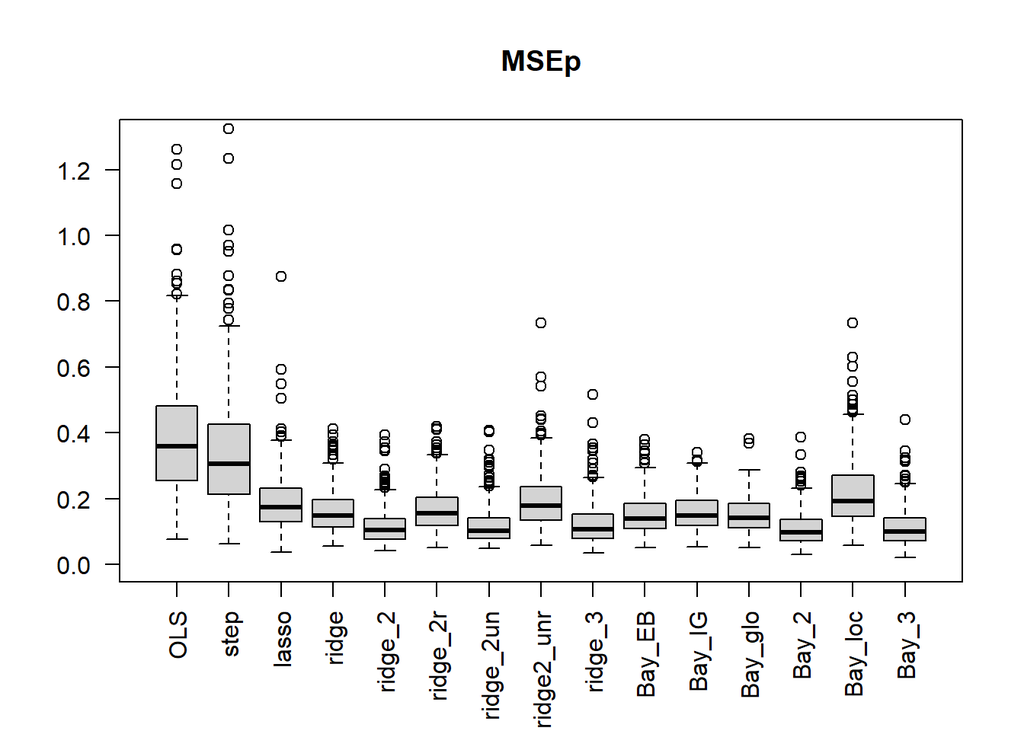

```r
cn <- colnames(pseplot)
par(las=2,xaxt="n")
boxplot(pseplot,ylim =c(0,1.3),main="MSEp")
par(las=2,xaxt="s")
axis(1,at=1:length(cn),cn)
```

Comparing performance of 2-pen, 1-pen and 0-pen (OLS) for various sample sizes

```r
nseq <- seq(50,200,by=15)
if(dofit){
  system.time(allfits <- lapply(nseq,pencompare3n,nfit=100))
  save(allfits, file="allfits_samplesize.Rdata")
  } else {
  setwd(wd)
  load("allfits_samplesize.Rdata")
  }

allmedians <- c()
for(k in 1:length(nseq)){
  print(nseq[k])
  fits <- allfits[[k]]
  coefs <- lapply(fits,coeffun,method="mgcv")
  nfit <- length(coefs)
  sets <- makeTraining(nseq[k],nfit=nfit)
  psemgcv <- t(RPSE(coefs,sets=sets))
  colnames(psemgcv) <- c("OLS","ridge","ridge_2")
  medians <- apply(psemgcv,2,median)
  allmedians<-rbind(allmedians,medians)
}
```

```
## [1] 50
## [1] 65
## [1] 80
## [1] 95
## [1] 110
## [1] 125
## [1] 140
## [1] 155
## [1] 170
## [1] 185
## [1] 200
```

```r
allmedians
```

```
##                OLS      ridge    ridge_2
## medians 0.34265822 0.14322883 0.09941379
## medians 0.24196625 0.12367278 0.08806882
## medians 0.19518639 0.09765047 0.07610191
## medians 0.15878240 0.09707615 0.07321966
## medians 0.12146492 0.07964423 0.06423274
## medians 0.10936224 0.07400975 0.05814347
## medians 0.09305170 0.06596186 0.05700905
## medians 0.08587789 0.06065747 0.05367704
## medians 0.08044201 0.05571459 0.04781112
## medians 0.07486035 0.05573670 0.05002207
## medians 0.06389919 0.04872520 0.04366963
```

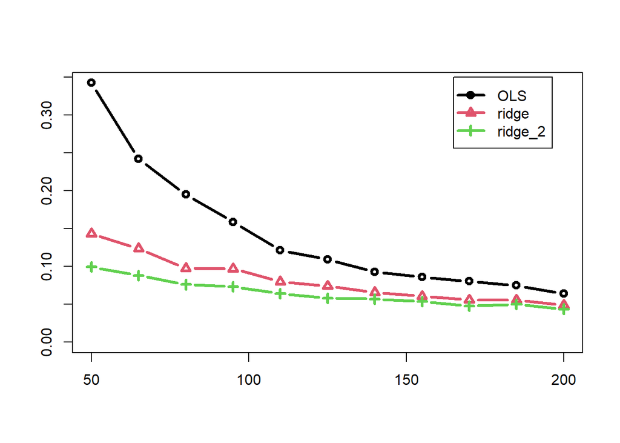

```r
plot(nseq,allmedians[,1],pch=1,type="b",ylim=c(0,allmedians[1,1]),xlab="",ylab="",lwd=3)
points(nseq,allmedians[,2],lty=1,col=2,pch=2,type="b",lwd=3)
points(nseq,allmedians[,3],lty=1,col=3,pch=3,type="b",lwd=3)
legend(165,0.35,legend=c("OLS","ridge","ridge_2"),col=1:3,lty=1,lwd=3,pch=1:3)
```

### Evaluating Calibration (cslopes)

```r
nsub <- 50
if(nsub == 50) sets <- td50_400 else sets <- td200_400_4
```

Compute cslopes per subset and method. Takes a minute

```r
cbbayset <- calibrateperset(coefsbayes,sets,c(3,4,6))
```

```
## [1] 50
## [1] 100
## [1] 150
## [1] 200
## [1] 250
## [1] 300
## [1] 350
## [1] 400
```

```r
cbset <- calibrateperset(coefsmgcv,sets,c(1,3,4))
```

```
## [1] 50
## [1] 100
## [1] 150
## [1] 200
## [1] 250
## [1] 300
## [1] 350
## [1] 400
```

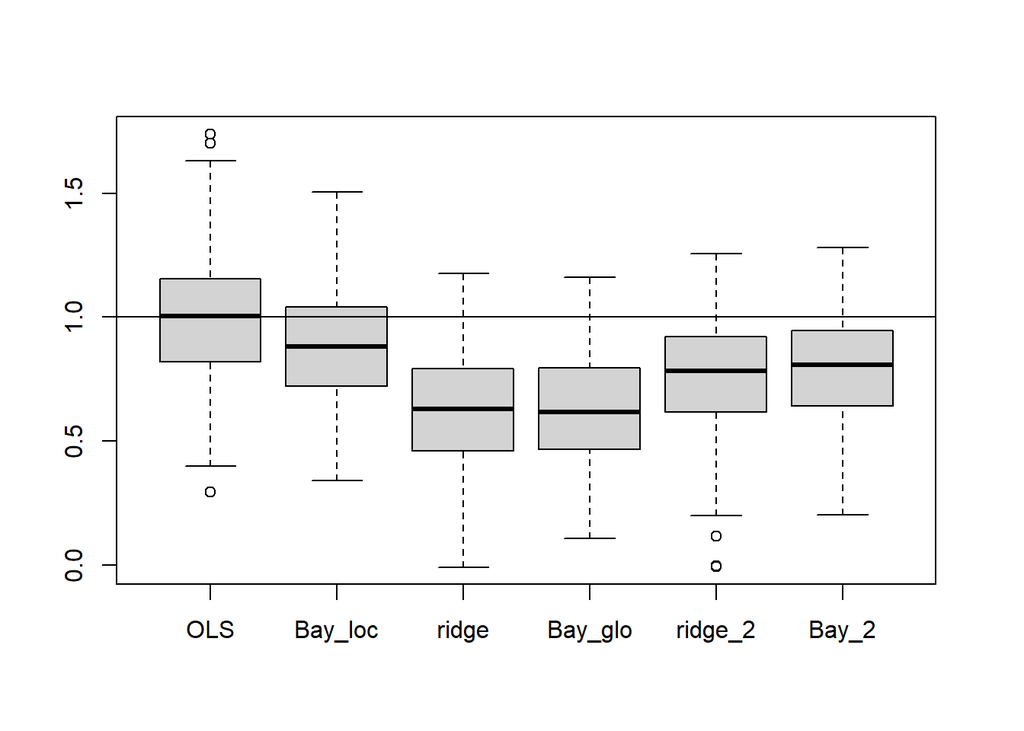

```r
slopemat0 <- cbind(cbset,cbbayset)
slopemat<- slopemat0[,c(1,6,2,4,3,5)]
colnames(slopemat) <- c("OLS", "Bay_loc","ridge","Bay_glo","ridge_2","Bay_2")

par(mar=c(5,4,4,3))
boxplot(slopemat,xlab="",main="")
abline(h=1)
```

rmses of the slopes

```r
for(k in 1:6) print(sqrt(mean((slopemat[,k]-1)^2)))
```

```
## [1] 0.2392741
## [1] 0.2373012
## [1] 0.4497386
## [1] 0.4394931
## [1] 0.3244326
## [1] 0.2950296
```

### Explaining (mis)-calibration: coefficient of BMI

Plot coefficients and the truth for BMI

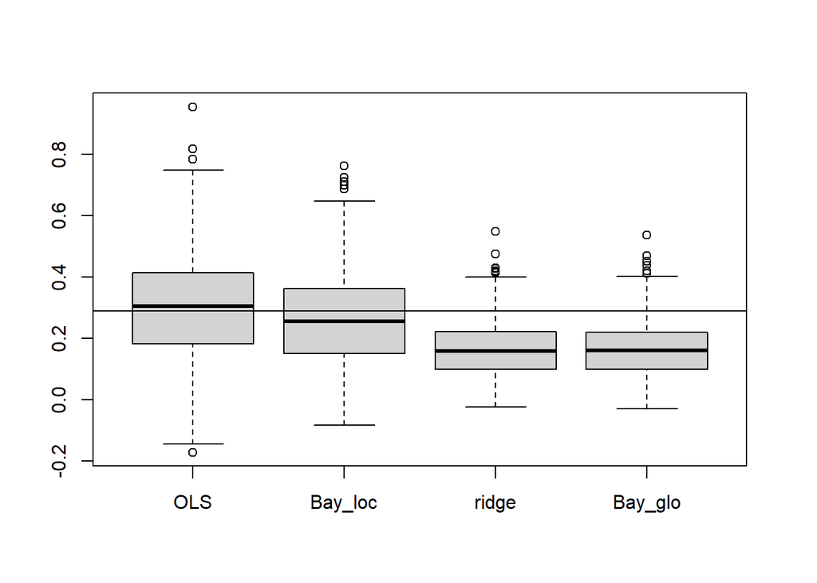

```r
coefBMIOLS <- unlist(lapply(coefsmgcv,function(mat) mat[11,1]))
coefBMIridge <- unlist(lapply(coefsmgcv,function(mat) mat[11,3]))
coefBMIBayGlo <- unlist(lapply(coefsbayes,function(mat) mat[11,3]))
coefBMIBayLoc <- unlist(lapply(coefsbayes,function(mat) mat[11,6]))
coefsBMI <- cbind(coefBMIOLS,coefBMIBayLoc,coefBMIridge,coefBMIBayGlo)

par(mar=c(5,4,4,3))
colnames(coefsBMI) <-  c("OLS","Bay_loc","ridge","Bay_glo")
boxplot(coefsBMI)
abline(h=effsize[11])
```

Extremes for OLS

```r
maxols <- which.max(coefBMIOLS)
minols <- which.min(coefBMIOLS)
minmax <- c(minols,maxols)
```

Illustrate shrinkage on BMI coefficient

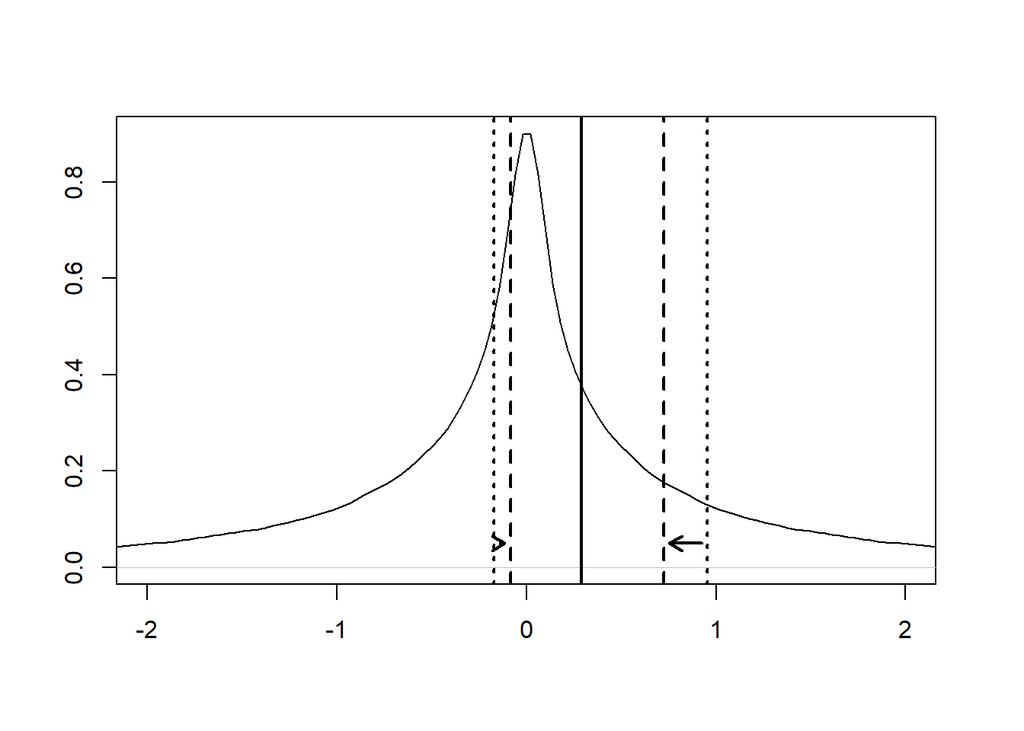

```r
nsam <- 100000
rnormcauchy <- rnorm(nsam,0,sd=abs(rcauchy(nsam)))
allrnc <- c(rnormcauchy,-rnormcauchy)
wh <- which(abs(allrnc)<=10)
par(mar=c(5,4,4,3))
plot(density(allrnc[wh]),xlim=c(-2,2),xlab="",ylab="",main="")
abline(v=coefBMIOLS[minols],lty=3,lwd=2)
abline(v=coefBMIBayLoc[minols],lty=2,lwd=2)
abline(v=coefBMIOLS[maxols],lty=3,lwd=2)
abline(v=coefBMIBayLoc[maxols],lty=2,lwd=2)
arrows(coefBMIOLS[minols]+0.03, 0.05, x1 = coefBMIBayLoc[minols] -0.03, y1 = 0.05,length=0.1,lwd=2)
arrows(coefBMIOLS[maxols]-0.03, 0.05, x1 = coefBMIBayLoc[maxols] +0.03, y1 = 0.05,code=2,length=0.1,lwd=2)
abline(v=effsize[11],lwd=2)
```

### Variability of ridge penalties

Assumes nsub is set (to 50 or 200) and fitting results have been loaded (see above)

Retrieve ridge penalties from mgcv results

```r
pensmgcv <- t(sapply(1:length(penCmgcv),
                   function(i){
                     penC1 <- penCmgcv[[i]]
                     pen1mml <- penC1$pred1$sp
                     pen2mml <- penC1$pred2$sp
                     return(c(pen1mml,pen2mml))
                   }
                   ))
colnames(pensmgcv) <- c("pen1mml","pen2mml_1","pen2mml_2")
```

Retrieve penalties from Bayes global (posterior mode)

```r
pensbayglo <- 1/t(sapply(1:length(penCbayes),
                       function(i){
                         #i<-1
                         penC1 <- penCbayes[[i]]
                         pens<-sapply(c(1,3),function(i){ex <- penC1[[i]];
                         if(i==1) return(ex$tau2s_summary[1]) else return(ex$tau2s_summary[8])
                         })
                         return(pens)
                       }
))
colnames(pensbayglo) <-  c("Bay_ridgeMML","Bay_glo")
```

Retrieve penalties from Bay_2 (posterior mode)

```r
pensbay2 <- 1/t(sapply(1:length(penCbayes),
                         function(i){
                           penC1 <- penCbayes[[i]]
                           pens<-sapply(c(4),function(i){ex <- penC1[[i]];
                           if(i==1) return(ex$tau2s_summary[1]) else return(ex$tau2s_summary[2:3,8])
                           })
                           return(pens)
                         }
))
```

Retrieve posterior intervals

```r
penintervals <- 1/t(sapply(1:length(penCbayes),
                      function(i){
                        inter <- penCbayes[[i]][[3]]$tau2s_summary[c(6,5,4)]
                        return(inter)
                      }
                        ))

pensboth <- cbind(pensmgcv[,1],pensbayglo[,2])
```

Plot variability of penalties; between subsets (left-side), within subsets (right side; Bayesian estimate)

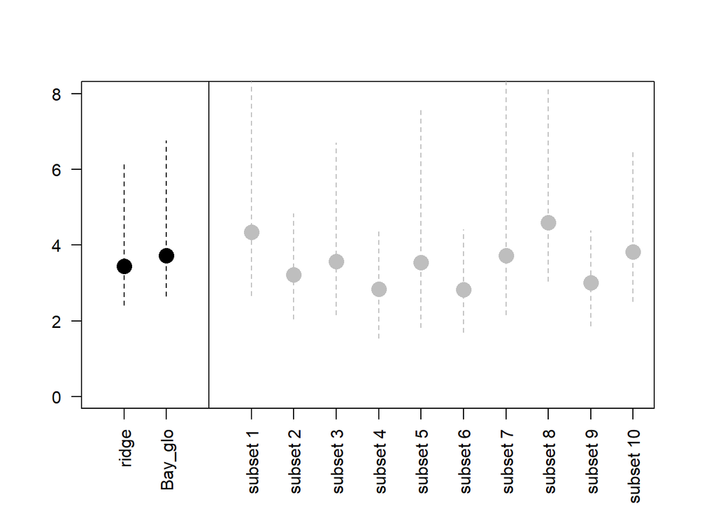

```r
par(las=2,xaxt="n",mar=c(5,4,4,3))
for(i in 1:2){
  #i<-1
  pb <- log(pensboth[,i])
mediani <- median(pb)
q025i <- quantile(pb,probs=c(0.025,0.975))
if(i==1) plot(i,mediani, cex=2, pch=16, xlim=c(0.5,13),xlab="",  ylim=c(0,8),
              ylab="") else points(i,mediani, cex=2, pch=16)
segments(i,q025i[1],i,q025i[2],lty=2)
}
sqint <- log(penintervals)
set.seed(34534)
set10 <- sample(1:nrow(sqint),10)
for(j in 1:10){
  indj <- set10[j]
  modej <- sqint[indj,2]
  points(j+3,modej, cex=2, pch=16, col="grey")
  segments(j+3,sqint[indj,1],j+3,sqint[indj,3],lty=2,col="grey")


}
abline(v=3)
par(las=2,xaxt="s")
axis(1,at=c(1:2,4:13),c("ridge", "Bay_glo",paste("subset",1:10)))
```

Plot variability of penalties, two covariate group setting. Note: missings may occur, but are rare, so ignored

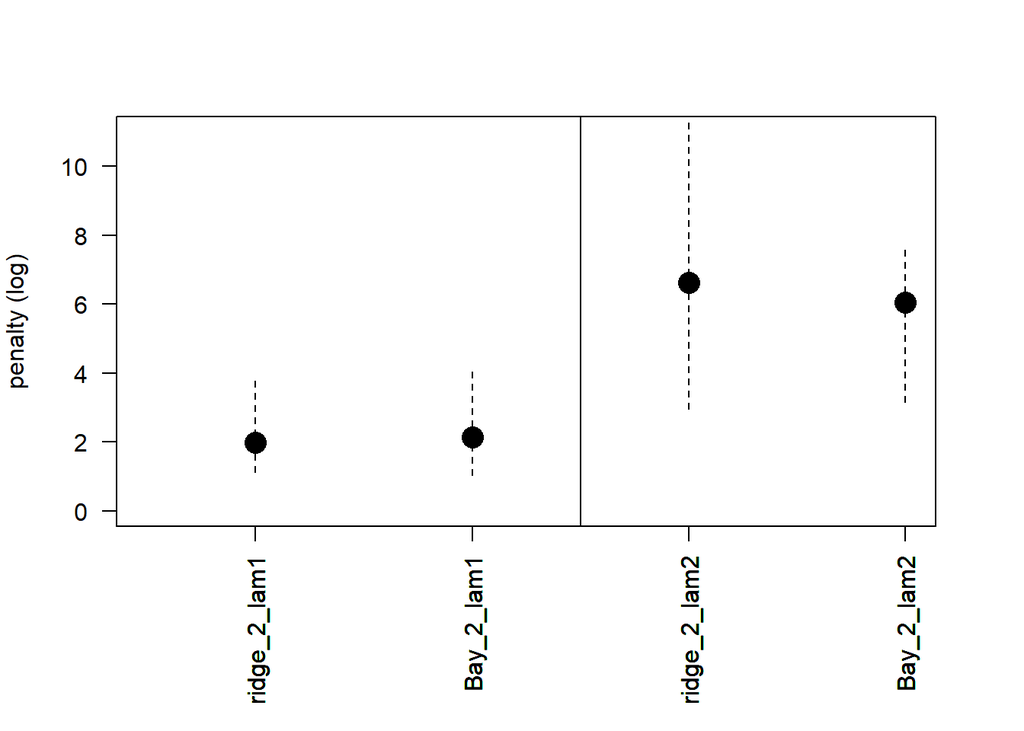

```r
pensfour <- cbind(pensmgcv[,2],pensbay2[,2],pensmgcv[,3],pensbay2[,1])
par(las=2,xaxt="n",mar=c(7,4,4,3))
for(i in 1:4){
  #i<-1
  pb <- log(pensfour[,i])
  mediani <- median(pb,na.rm=T)
  q025i <- quantile(pb,probs=c(0.025,0.975),na.rm=T)
  if(i==1) plot(i,mediani, cex=2, pch=16, xlim=c(0.5,4),xlab="",  ylim=c(0,11),ylab="penalty (log)") else points(i,mediani, cex=2, pch=16)
  #points(i,mediani+sdi,cex=2,pch=25,bg="grey")
  segments(i,q025i[1],i,q025i[2],lty=2)
  abline(v=2.5)
  par(las=2,xaxt="s")
  axis(1,at=1:4,c("ridge_2_lam1", "Bay_2_lam1","ridge_2_lam2", "Bay_2_lam2"))
}
```

## Coverage of confidence intervals of predictions

Assumes nsub is set (to 50 or 200) and fitting results have been loaded (see above)

```r
nfit <- length(penCmgcv)
```

Coverage test sets predictions for OLS, ridge, ridge2 per training data set

```r
coverridges <- sapply(c(1,3,4),covermgcv,fit=penCmgcv,uncond = T,bench=predtrue,testind=testfixedind)
```

```
## [1] 50
## [1] 100
## [1] 150
## [1] 200
## [1] 250
## [1] 300
## [1] 350
## [1] 400
## [1] 50
## [1] 100
## [1] 150
## [1] 200
## [1] 250
## [1] 300
## [1] 350
## [1] 400
## [1] 50
## [1] 100
## [1] 150
## [1] 200
## [1] 250
## [1] 300
## [1] 350
## [1] 400
```

Quantiles across data sets of coverages of OLS, ridge, ridge2

```r
coversr <- apply(coverridges,2,quantile,probs=c(0.1,0.5,0.9))
colnames(coversr) <- c("OLS","ridge", "ridge2")
coversr
```

```
##        OLS ridge ridge2
## 10% 0.9225 0.830 0.7450
## 50% 0.9375 0.955 0.9225
## 90% 0.9550 0.985 0.9675
```

```r
covmeanr <- apply(coverridges,2,mean)
```

Coverage test sets predictions for Bay_loc, Bay_glo, Bay2 per training data set

```r
coverbayess <- sapply(c(6,3,4),coverbayes,fit=penCbayes, testind=testfixedind, bench=predtrue)
```

Quantiles across data sets of coverages of Bay_loc, Bay_glo, Bay2

```r
coversb <- apply(coverbayess,2,quantile,probs=c(0.1,0.5,0.9))
colnames(coversb) <- c("Bay_loc","Bay_glo", "Bay2")
coversb
```

```
##     Bay_loc Bay_glo   Bay2
## 10%   0.950  0.8725 0.9050
## 50%   0.975  0.9775 0.9750
## 90%   0.990  0.9950 0.9925
```

```r
covmeanb <- apply(coverbayess,2,mean)
```

Widths of intervals for OLS, ridge, ridge2 per training data set

```r
widthridges <- sapply(c(1,3,4),widthmgcv,fit=penCmgcv,uncond = T,bench=predtrue,testind=testfixedind)
```

```
## [1] 50
## [1] 100
## [1] 150
## [1] 200
## [1] 250
## [1] 300
## [1] 350
## [1] 400
## [1] 50
## [1] 100
## [1] 150
## [1] 200
## [1] 250
## [1] 300
## [1] 350
## [1] 400
## [1] 50
## [1] 100
## [1] 150
## [1] 200
## [1] 250
## [1] 300
## [1] 350
## [1] 400
```

```r
widthsr <- apply(widthridges,2,quantile,probs=c(0.1,0.5,0.9))
colnames(widthsr) <- c("OLS","ridge", "ridge2")
widthsr
```

```
##          OLS    ridge    ridge2
## 10% 1.819418 1.207650 0.9805921
## 50% 2.303991 1.494798 1.1967137
## 90% 2.823932 1.830201 1.4690167
```

```r
widmeanr <- apply(widthridges,2,mean)
```

Widths of intervals for Bay_loc, Bay_glo, Bay2 per training data set

```r
widthbayess <- sapply(c(6,3,4),widthbayes,fit=penCbayes, testind=testfixedind, bench=predtrue)
widthsb <- apply(widthbayess,2,quantile,probs=c(0.1,0.5,0.9))
colnames(widthsb) <- c("Bay_loc","Bay_glo", "Bay2")
widthsb
```

```
##      Bay_loc  Bay_glo     Bay2
## 10% 1.878927 1.359362 1.251361
## 50% 2.117150 1.582551 1.445557
## 90% 2.433026 1.886817 1.717448
```

```r
widmeanb <- apply(widthbayess,2,mean)
```

Summary table comparing frequentist (F) results with its Bayesian (B) counterpart

```r
allmean <- round(cbind(covmeanr,covmeanb,widmeanr,widmeanb),3)
rownames(allmean) <- c("OLS (F) and Bay_loc (B)","ridge (F) and Bay_glo (B)", "ridge2 (F) and Bay2 (B)")
colnames(allmean) <- c("Cov,F", "Cov,B", "Width,F", "Width,B")

allmean
```

```
##                           Cov,F Cov,B Width,F Width,B
## OLS (F) and Bay_loc (B)   0.938 0.972   2.324   2.144
## ridge (F) and Bay_glo (B) 0.929 0.953   1.512   1.608
## ridge2 (F) and Bay2 (B)   0.887 0.959   1.221   1.473
```